# Project1

Dave Lofte

Monday, February 09, 2015

### Loading in the data

```r
library(ggplot2)
library(dplyr)
unzip('activity.zip')
activity <- read.csv("activity.csv")
str(activity)
```

```
## 'data.frame':    17568 obs. of  3 variables:
##  $ steps   : int  NA NA NA NA NA NA NA NA NA NA ...
##  $ date    : Factor w/ 61 levels "2012-10-01","2012-10-02",..: 1 1 1 1 1 1 1 1 1 1 ...
##  $ interval: int  0 5 10 15 20 25 30 35 40 45 ...
```

```r
activity[,2] <- as.Date(activity$date)
summary(activity[,2])
```

```
##         Min.      1st Qu.       Median         Mean      3rd Qu.
## "2012-10-01" "2012-10-16" "2012-10-31" "2012-10-31" "2012-11-15"
##         Max.
## "2012-11-30"
```

```r
time <- paste(activity$date, activity$interval)
```

```r
group_by(activity,date, interval)
```

```
## Source: local data frame [17,568 x 3]
## Groups: date, interval
##
##    steps       date interval
## 1     NA 2012-10-01        0
## 2     NA 2012-10-01        5
## 3     NA 2012-10-01       10
## 4     NA 2012-10-01       15
## 5     NA 2012-10-01       20
## 6     NA 2012-10-01       25
## 7     NA 2012-10-01       30
## 8     NA 2012-10-01       35
## 9     NA 2012-10-01       40
## 10    NA 2012-10-01       45
## ..   ...        ...      ...
```

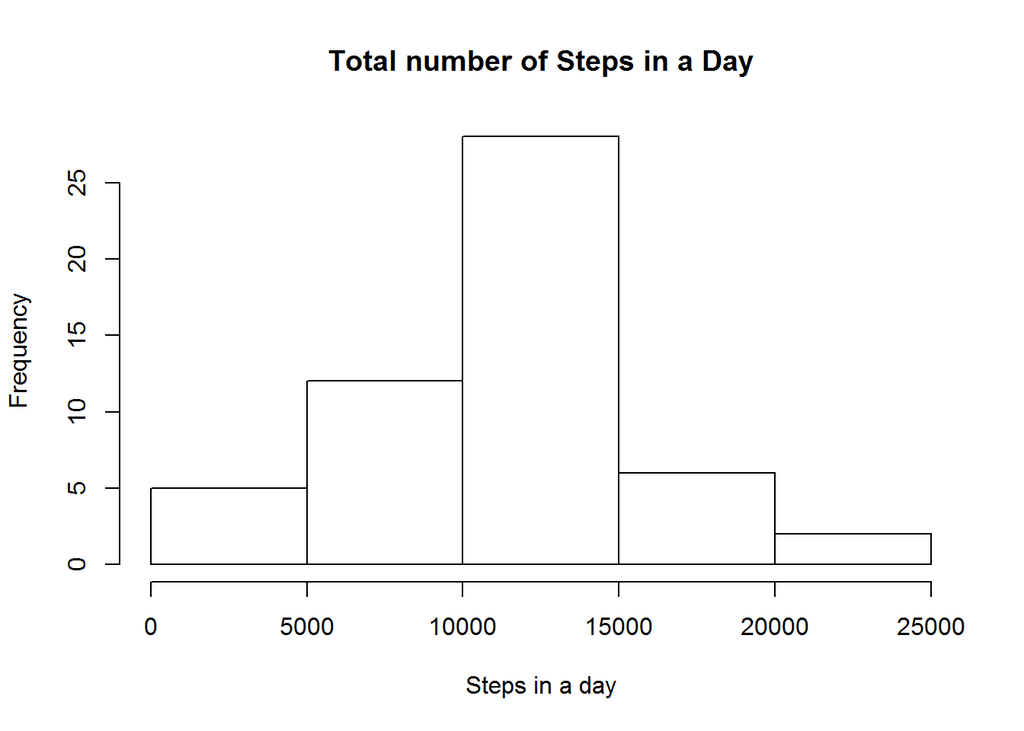

```r
byDay <- summarize(group_by(activity, date), totalSteps=sum(steps))
par(mfrow = c(1,1))
hist(byDay$totalSteps, main = "Total number of Steps in a Day", xlab = "Steps in a day")
```

We find the mean/median by day and create a table with the results, we see lots of NA or 0’s.

```r
meanByDay <- summarize(group_by(activity, date), meanSteps = mean(steps))
medianByDay <- summarize(group_by(activity, date), medianSteps = median(steps))

results <- left_join(byDay, meanByDay)
results <- left_join(results, medianByDay)
results
```

```
## Source: local data frame [61 x 4]
##
##          date totalSteps meanSteps medianSteps
## 1  2012-10-01         NA        NA          NA
## 2  2012-10-02        126   0.43750           0
## 3  2012-10-03      11352  39.41667           0
## 4  2012-10-04      12116  42.06944           0
## 5  2012-10-05      13294  46.15972           0
## 6  2012-10-06      15420  53.54167           0
## 7  2012-10-07      11015  38.24653           0
## 8  2012-10-08         NA        NA          NA
## 9  2012-10-09      12811  44.48264           0
## 10 2012-10-10       9900  34.37500           0
## ..        ...        ...       ...         ...
```

Create plots showing the average/median number of steps by time interval

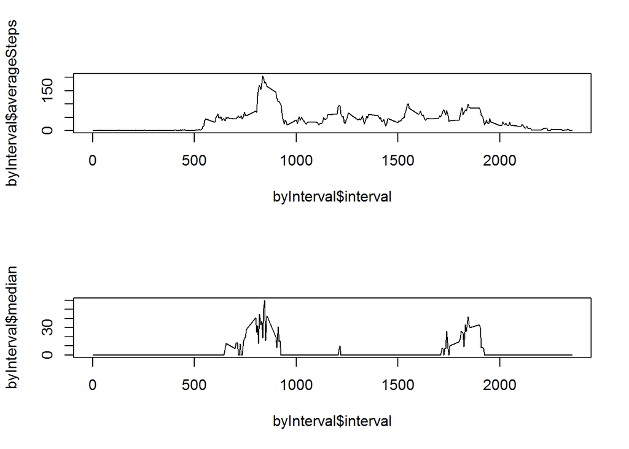

```r
byInterval <-summarize(group_by(activity, interval ), averageSteps = mean(steps, na.rm = T), median = median(steps, na.rm = T))

par(mfrow = c(2,1))
plot(byInterval$interval, byInterval$averageSteps, type = 'l')
plot(byInterval$interval, byInterval$median, type = 'l')
```

Let’s find the interval with the max number of average steps

```r
byInterval[byInterval$averageSteps == max(byInterval$averageSteps),]
```

```
## Source: local data frame [1 x 3]
##
##   interval averageSteps median
## 1      835     206.1698     19
```

## Imputing Missing values

1. Calculate and report the total number of missing values in the data set

```r
summary(activity)
```

```
##      steps             date               interval
##  Min.   :  0.00   Min.   :2012-10-01   Min.   :   0.0
##  1st Qu.:  0.00   1st Qu.:2012-10-16   1st Qu.: 588.8
##  Median :  0.00   Median :2012-10-31   Median :1177.5
##  Mean   : 37.38   Mean   :2012-10-31   Mean   :1177.5
##  3rd Qu.: 12.00   3rd Qu.:2012-11-15   3rd Qu.:1766.2
##  Max.   :806.00   Max.   :2012-11-30   Max.   :2355.0
##  NA's   :2304
```

We see from the summary that all the NA values are located in the “steps” column and that there are 2304 missing values or NA values

2. I think replacing by average value by interval will give us a fair guestimate. Average by day is unsatisfactory since some days are composed entirely of missing values, such as the first day. Replacing by median by interval results in many 0 values, which isn’t as interesting?
3. I am creating a new data frame ‘newActivity’ with all the NA values replaced by the mean by interval.

```r
newActivity <- activity
for (int in newActivity$interval){
    tempMean <- mean(newActivity$steps[newActivity$interval == int], na.rm=T)
    newActivity[newActivity$interval == int & is.na(newActivity)] <- tempMean
}
summary(newActivity)
```

```
##      steps             date               interval
##  Min.   :  0.00   Min.   :2012-10-01   Min.   :   0.0
##  1st Qu.:  0.00   1st Qu.:2012-10-16   1st Qu.: 588.8
##  Median :  0.00   Median :2012-10-31   Median :1177.5
##  Mean   : 37.38   Mean   :2012-10-31   Mean   :1177.5
##  3rd Qu.: 27.00   3rd Qu.:2012-11-15   3rd Qu.:1766.2
##  Max.   :806.00   Max.   :2012-11-30   Max.   :2355.0
```

```r
head(newActivity)
```

```
##       steps       date interval
## 1 1.7169811 2012-10-01        0
## 2 0.3396226 2012-10-01        5
## 3 0.1320755 2012-10-01       10
## 4 0.1509434 2012-10-01       15
## 5 0.0754717 2012-10-01       20
## 6 2.0943396 2012-10-01       25
```

Creating a histogram of the total number of steps by day of our NA free newActivity data

```r
group_by(newActivity,date, interval)
```

```
## Source: local data frame [17,568 x 3]
## Groups: date, interval
##
##        steps       date interval
## 1  1.7169811 2012-10-01        0
## 2  0.3396226 2012-10-01        5
## 3  0.1320755 2012-10-01       10
## 4  0.1509434 2012-10-01       15
## 5  0.0754717 2012-10-01       20
## 6  2.0943396 2012-10-01       25
## 7  0.5283019 2012-10-01       30
## 8  0.8679245 2012-10-01       35
## 9  0.0000000 2012-10-01       40
## 10 1.4716981 2012-10-01       45
## ..       ...        ...      ...
```

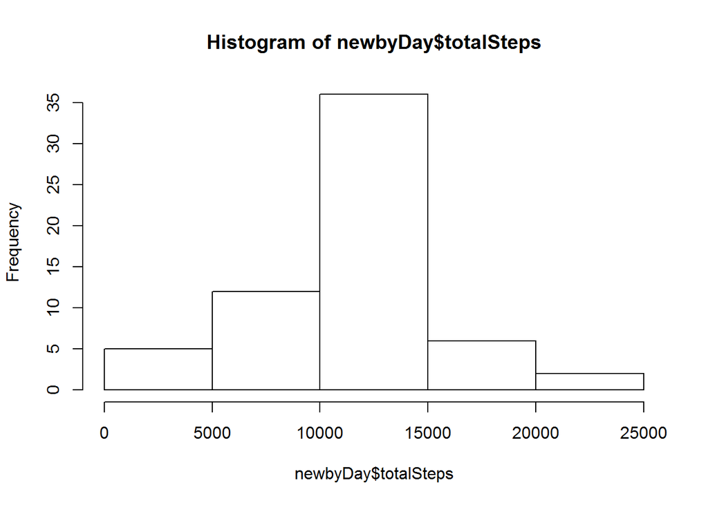

```r
newbyDay <- summarize(group_by(newActivity, date), totalSteps=sum(steps))

hist(newbyDay$totalSteps)
```

```r
newActivity[3,]
```

```
##       steps       date interval
## 3 0.1320755 2012-10-01       10
```

```r
newMeanByDay <- summarize(group_by(newActivity, date), meanSteps = mean(steps))
newMedianByDay <- summarize(group_by(newActivity, date), medianSteps = median(steps))
summary(newMedianByDay)
```

```
##       date             medianSteps
##  Min.   :2012-10-01   Min.   : 0.000
##  1st Qu.:2012-10-16   1st Qu.: 0.000
##  Median :2012-10-31   Median : 0.000
##  Mean   :2012-10-31   Mean   : 4.474
##  3rd Qu.:2012-11-15   3rd Qu.: 0.000
##  Max.   :2012-11-30   Max.   :34.113
```

```r
str(newMeanByDay)
```

```
## Classes 'tbl_df', 'tbl' and 'data.frame':    61 obs. of  2 variables:
##  $ date     : Date, format: "2012-10-01" "2012-10-02" ...
##  $ meanSteps: num  37.383 0.438 39.417 42.069 46.16 ...
##  - attr(*, "drop")= logi TRUE
```

```r
newResults <- left_join(newbyDay, newMeanByDay)
newResults <- left_join(newResults, newMedianByDay)
newResults
```

```
## Source: local data frame [61 x 4]
##
##          date totalSteps meanSteps medianSteps
## 1  2012-10-01   10766.19  37.38260    34.11321
## 2  2012-10-02     126.00   0.43750     0.00000
## 3  2012-10-03   11352.00  39.41667     0.00000
## 4  2012-10-04   12116.00  42.06944     0.00000
## 5  2012-10-05   13294.00  46.15972     0.00000
## 6  2012-10-06   15420.00  53.54167     0.00000
## 7  2012-10-07   11015.00  38.24653     0.00000
## 8  2012-10-08   10766.19  37.38260    34.11321
## 9  2012-10-09   12811.00  44.48264     0.00000
## 10 2012-10-10    9900.00  34.37500     0.00000
## ..        ...        ...       ...         ...
```

We compare the total of the Activity data. Column 1 is the total # of steps from the data with imputed values for NAs. Column 2 gives the total number of steps from the original data.

```r
cbind(sum(newResults$totalSteps), sum(results$totalSteps, na.rm = T))
```

```
##          [,1]   [,2]
## [1,] 656737.5 570608
```

Create a new “day” column containing factor variables inticating whether the day was a weekday or weekend.

```r
newActivity <- mutate(newActivity, day = weekdays(date))
newActivity[newActivity$day == "Saturday"| newActivity$day == 'Sunday',4] <- 'weekend'
newActivity[newActivity$day != 'weekend', 4] <- "weekday"
newActivity$day <- factor(newActivity$day, levels = c("weekend", "weekday"))
```

Plot the average number of steps by interval for both weekdays and weekends.

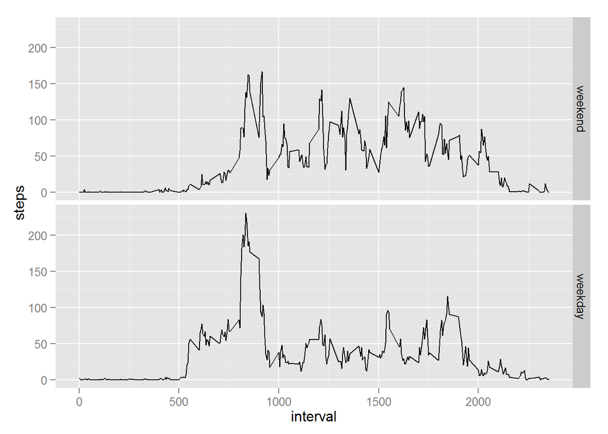

```r
bydayInterval <- summarize(group_by(newActivity,day, interval), steps = mean(steps))
qplot(interval, steps, data =bydayInterval, facets =day~., geom = 'line' )
```

```r
?qplot
```

```
## starting httpd help server ... done
```